# Covid Forecasting

Jose Tamez

4/9/2020

## Forcasting COVID-19 Deaths

A simple model for the estimation of the maximum percentage of deaths due to COVID-19.

NOTE: I’m not an epidiomiologist.

The prediction based on a simple logistic model and:

70% of SARS-CoV-2 exposure  
10% Infection efficacy ie. 10% of the exposure subjects turns into a Covid-19 case  
1% of Mortality

For each country we will use the urban population

I’ll estimate the death rates based on current trends fitted to the logistic function.  
The last 14 days will be used for the peak estimations. Peak estimations will be done using:

1. The last reported 14 observations
2. 14 observations from the last week
3. 14 observations ending two weeks ago
4. 14 observations ending three weeks ago
5. 14 observations ending four weeks ago

We are also providing optimistic models. We assume that the # of fatalities is one third the expected.

For Mexico we set the optimistic factor to 5. For every other country is set to 3.

### Source code:

https://github.com/joseTamezPena/COVID_Forecasting

```r
# The expetec %  of deaths in each country

expectedtotalFatalities = 0.7*0.1*0.01
optGain <- 3
mexicoGain <- 5
# The number of observations used for the trends
daysWindow <- 14
currentdate <- "April 8:"
```

### Loading the data

The data is the training set from: Kaggle: COVID19 Global Forecasting (Week 4)

https://www.kaggle.com/c/covid19-global-forecasting-week-4/data

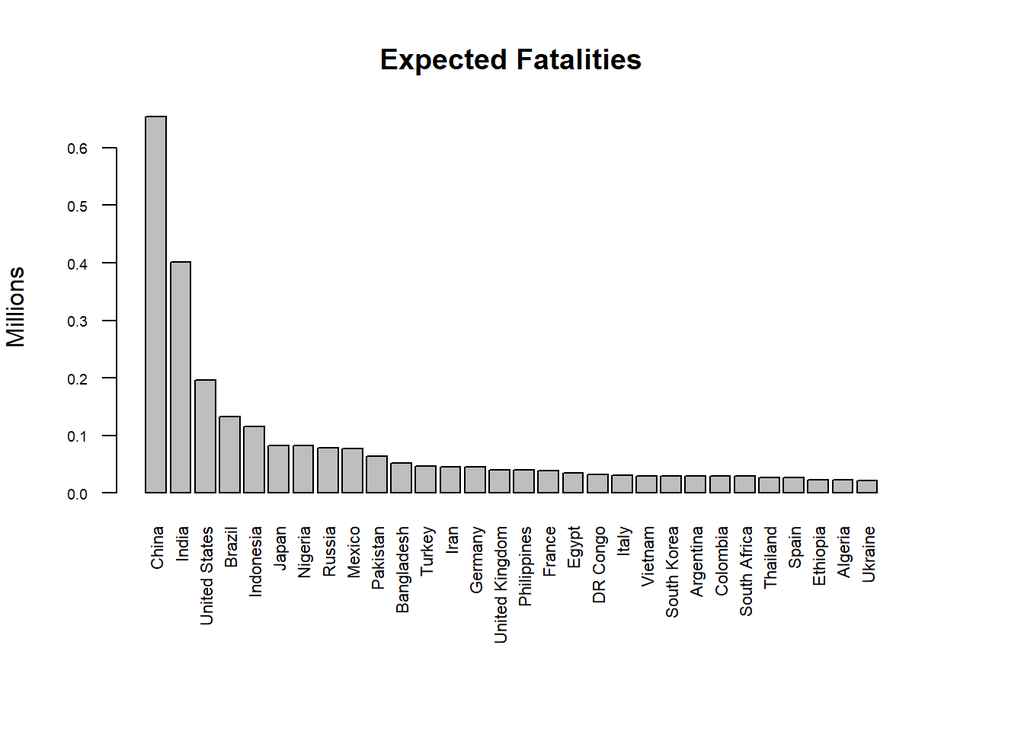

Ploting some trends

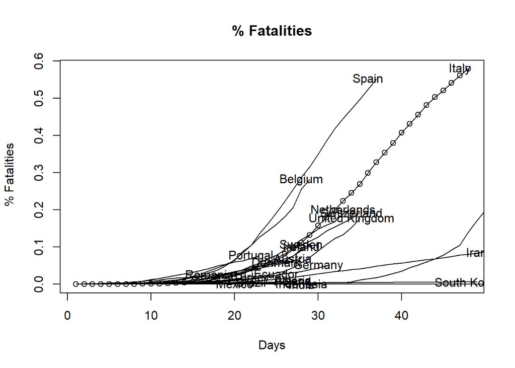

```r
Country_Region <- names(table(trainCountry$Country_Region))
totaldeaths <- numeric()
for (ctr in Country_Region)
{
   totaldeaths <- append(totaldeaths,max(trainCountry[trainCountry$Country_Region == ctr,"Fatalities"]))
}
names(totaldeaths) <- Country_Region
totaldeaths <- totaldeaths[order(-totaldeaths)]

plot(trainCountry[trainCountry$Country_Region == names(totaldeaths[1]),"PerFatalities"],main="% Fatalities",xlab="Days",ylab=" % Fatalities")
for (ctr in names(totaldeaths[1:25]))
{
  linp <- trainCountry[trainCountry$Country_Region == ctr,"PerFatalities"]
  lines(linp)
  text(length(linp)-1,linp[length(linp)],ctr)
}
```

```r
totaldeaths  <- totaldeaths[totaldeaths > 100]
```

## Trends Modeling Functions

## Estimating the peaks

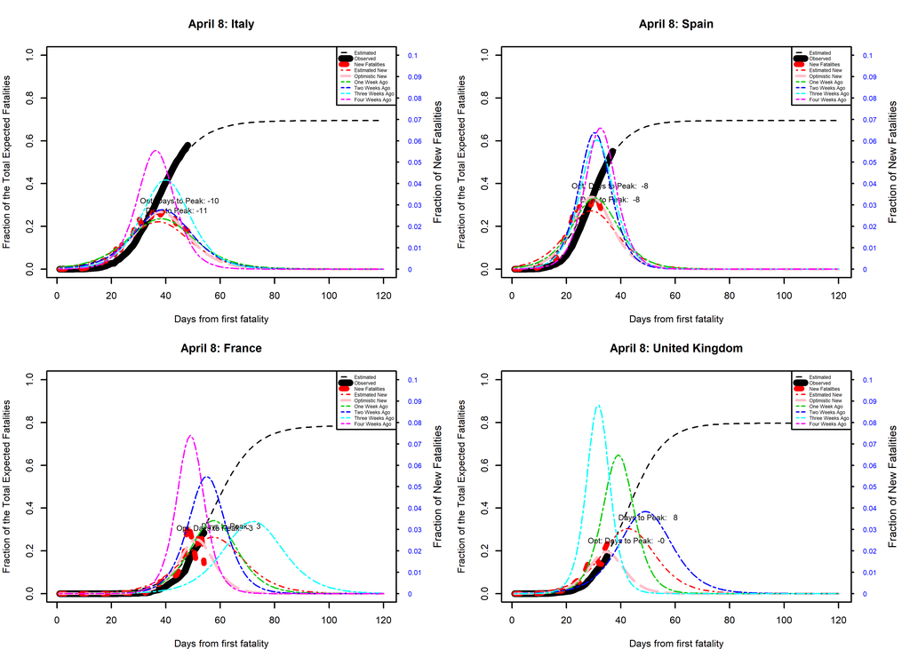

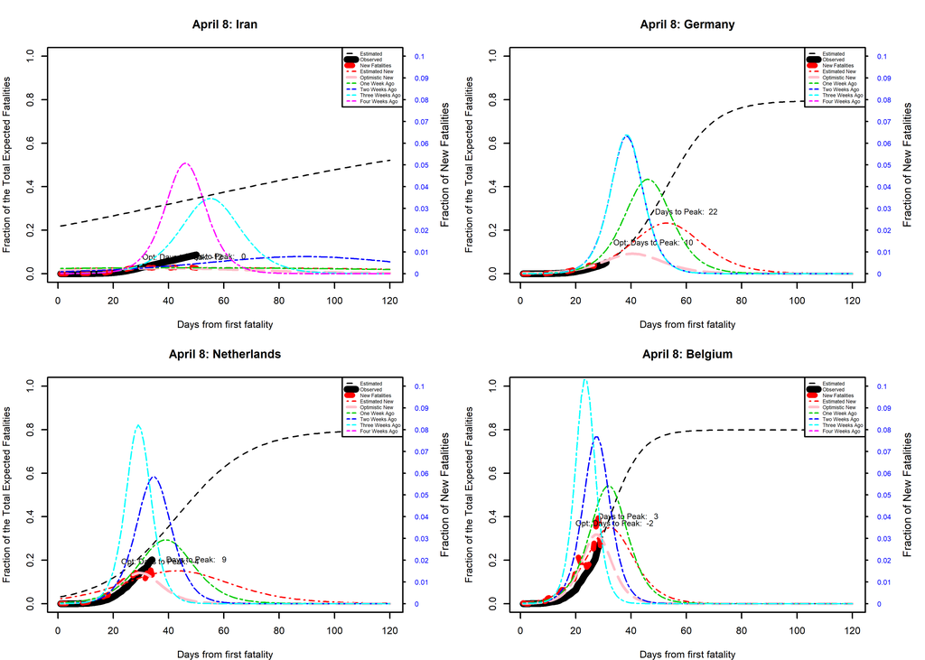

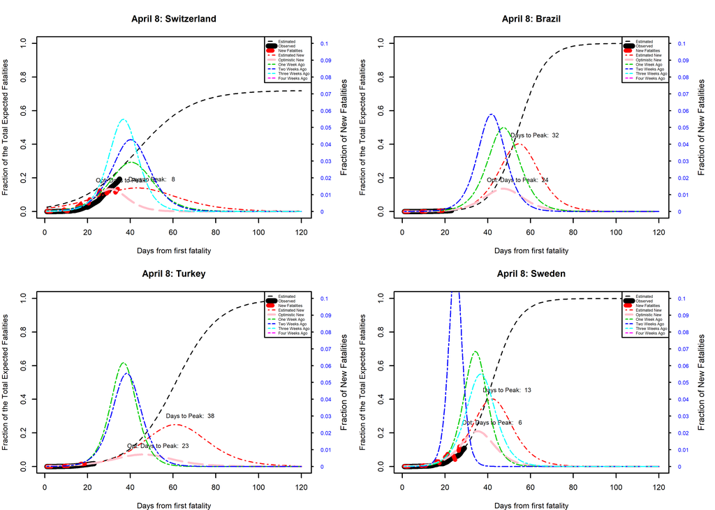

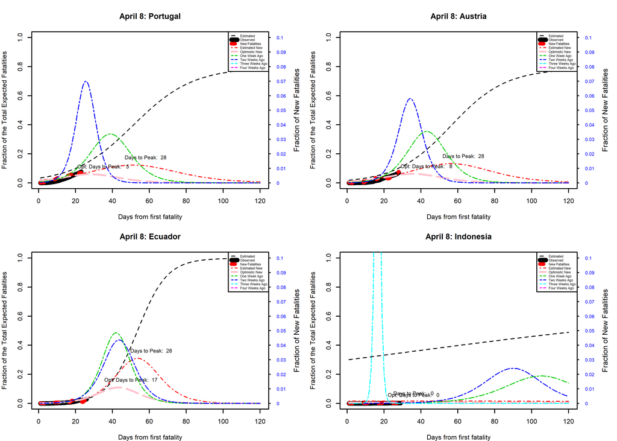

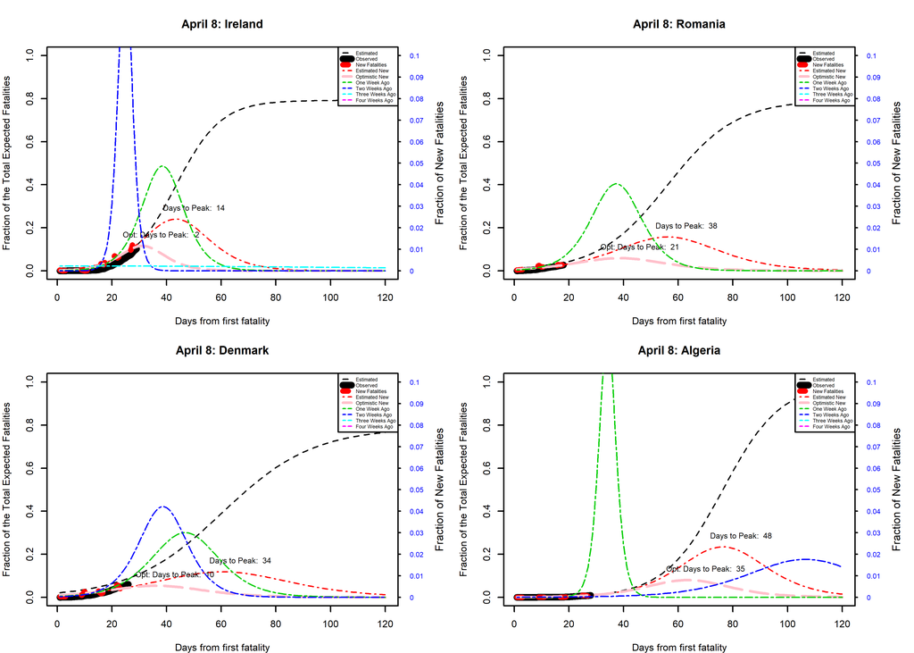

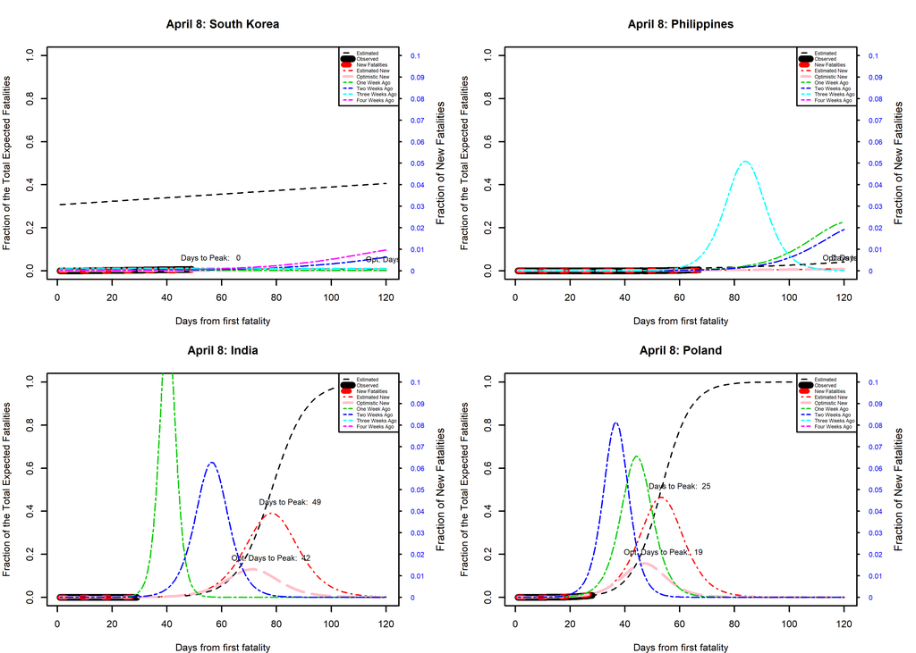

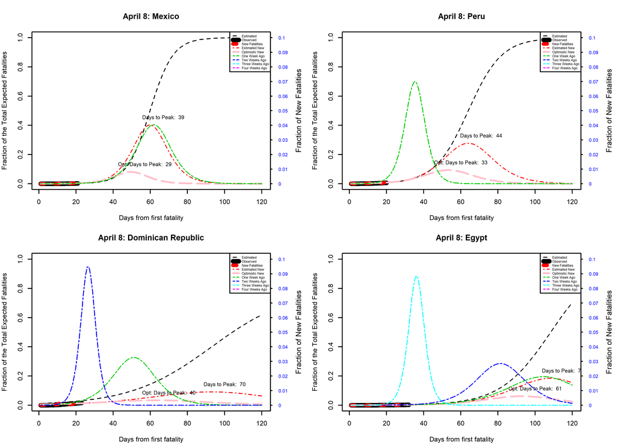

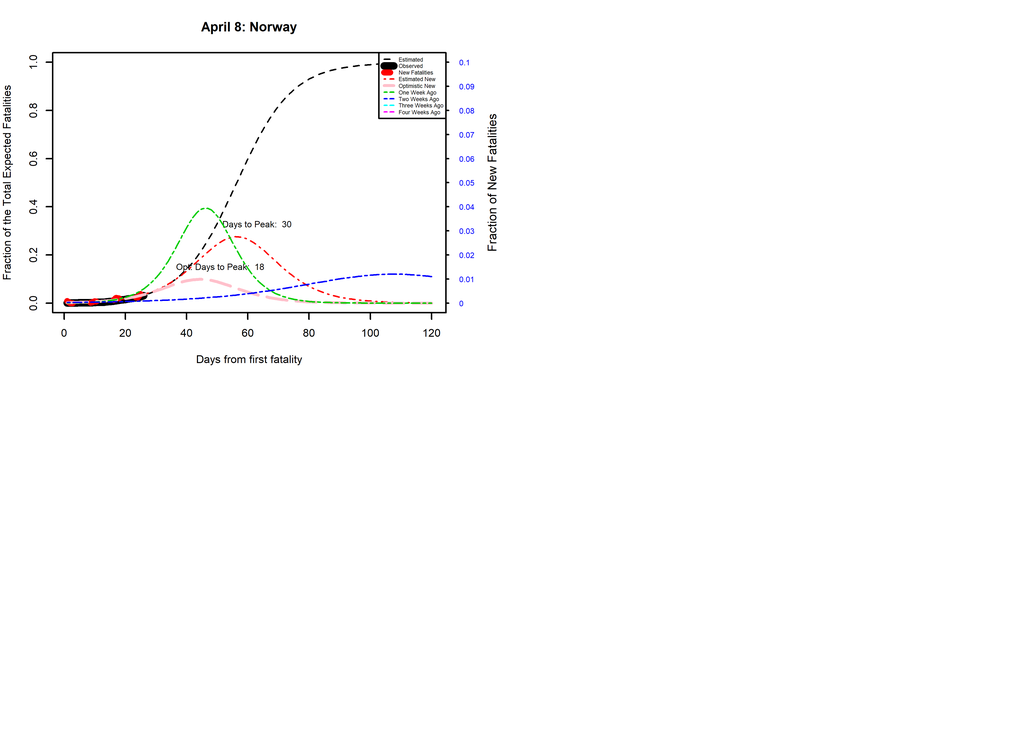

## Estimation by Province or State

## Estimating the State/Province Peaks

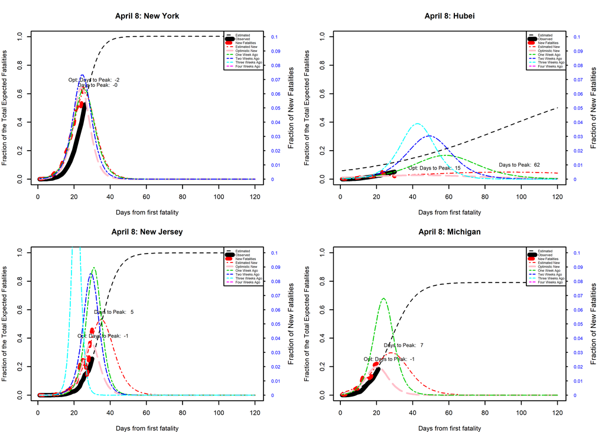

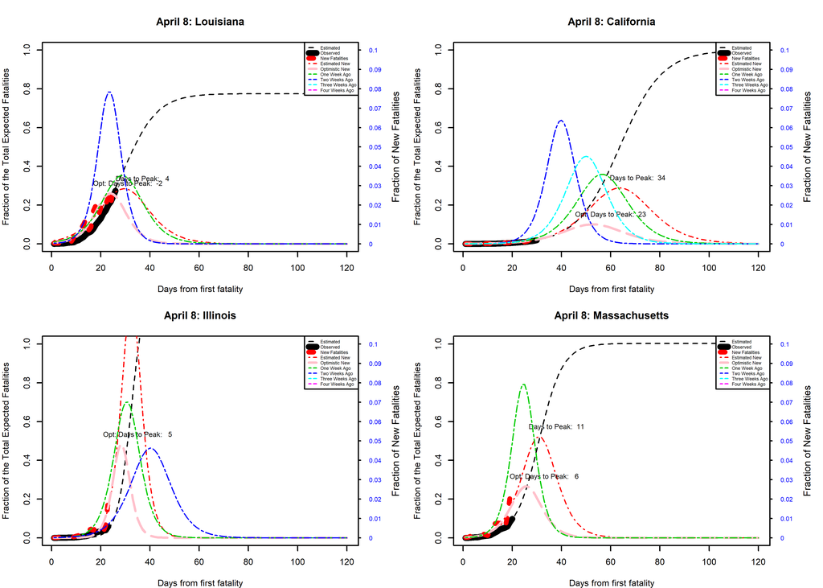

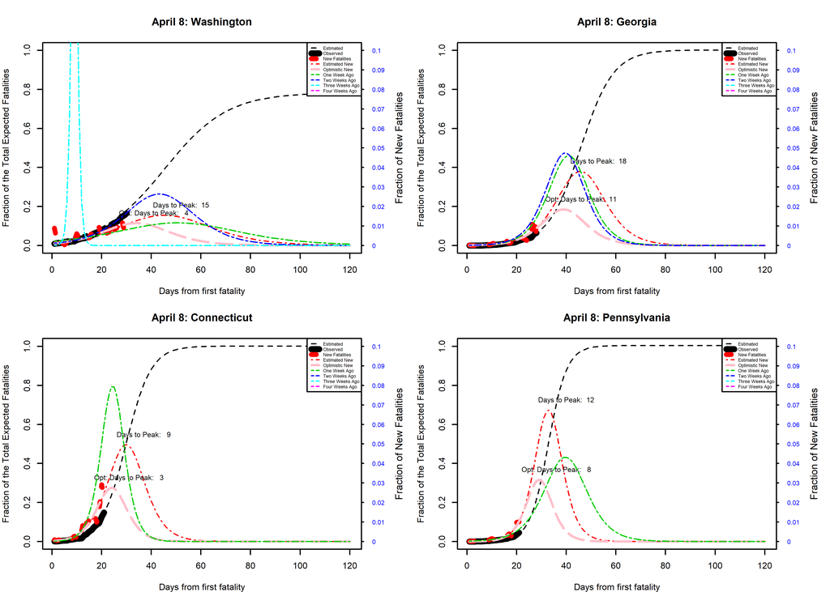

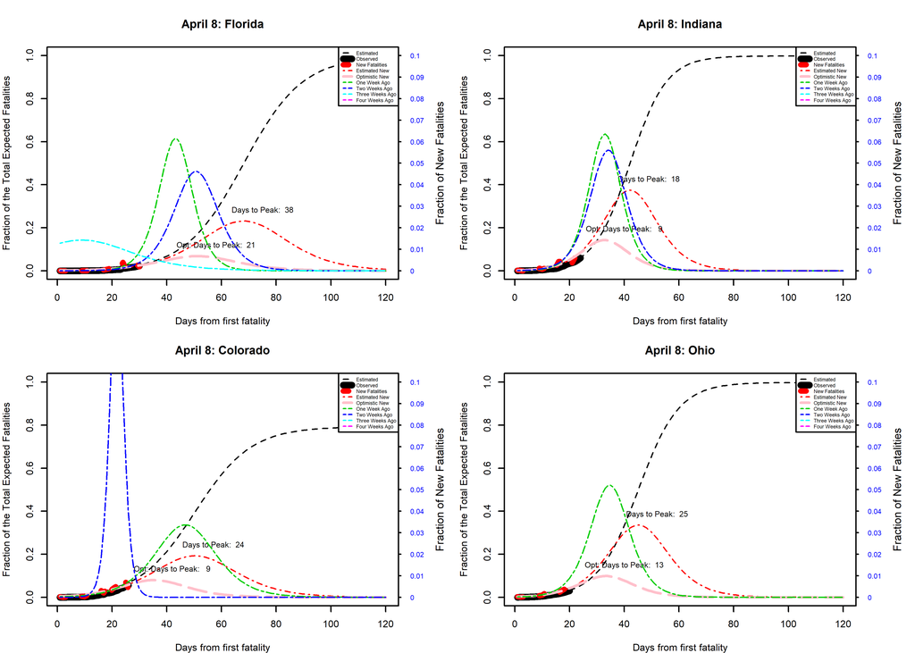

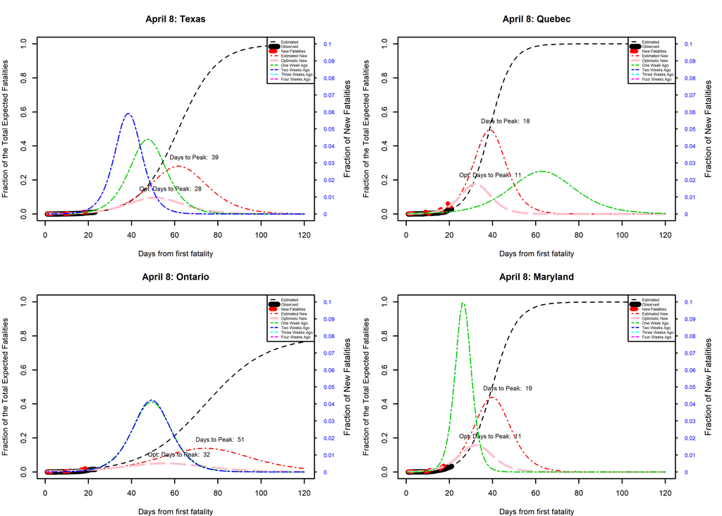